# My Approach to Research

7 September 2021

## Objective

Research is tough. Organizing is tough (especially for me). Organizing research is `#@$?&%` tough.

I’m going to share some stuff that has helped me (barely) keep it all together.

*Feel free to interrupt at any point. My mind is chaotic; why should the presentation be any different?*

## Outline

1. Software
2. Organization
3. Workflow
4. Special Topics

## Software

> If all you have is a hammer, everything looks like a nail. - Abraham Maslow

> It is essential to have good tools, but it is also essential that the tools should be used in the right way. - Wallace D. Wattles

> A good tool improves the way you work. A great tool improves the way you think. - Jeff Duntemann

The programs that I use:

- [R](https://www.r-project.org/) version 4.1.0 Camp Pontanezen
- [RStudio](https://www.rstudio.com/) desktop version 1.4.1106 Tiger Daylily
- [GitKraken](https://www.gitkraken.com/) version 7.7.2
- [Zotero](https://www.zotero.org/) 5.0.96.3
  - [ZotFile](http://zotfile.com/)
  - [Better BibTeX](https://retorque.re/zotero-better-bibtex/)
  - [Zotero Connector](https://www.zotero.org/download/connectors)

## Organization

[figure not shown]

xkcd

*Directory structure is the key.*

My approach…

- Think about where you would look for a given file and which locations you may access frequently (these should set the upper-level structure)
- Use numbers to order the folders in a way that makes sense (I think of them as building up to a final product)
- Play around with what feels right to you and what would make sense to others (big for collaboration)

Other approaches * [Cookiecutter Data Science](https://drivendata.github.io/cookiecutter-data-science/) * [DZone Data Science Project Folder Structure](https://dzone.com/articles/data-science-project-folder-structure)

- 00-Information
- 01-Data
  - 00-Raw-Data
  - 01-Processed-Data
  - 02-Clean-Data
- 02-Scripts
  - 01-Data-Managment-and-Cleaning
  - 02-Exploratory-Analysis
  - 03-Inferential-Analysis
- 03-Output
  - 01-Tables
  - 02-Figures
  - 03-Non-Static
- 04-Report
- 05-Miscellaneous

## Workflow

1. Orient goals of project
2. Create GitHub Repo
3. Create R Project
4. Setup Shell Directory
5. Populate Directory
6. Setup Zotero Collection
7. Code, Search, Analyze
8. Recode, Research, Reanalyze…
9. Report
10. Profit ;)

*7. Code, Search, Analyze*  
*8. Recode, Research, Reanalyze…*  
*9. Report*

This is where the programs listed before come in handy.

Typically, there are data that prompts the beginning of the project. I usually start with an R script to…

- Import the data
- *Wrangle* the data into a format conducive to analysis
- Clean the data (e.g., recode, calculate, set data types, etc.)
- Save the cleaned data to a native R file
  - .rds or .rdata

*This script should be the only one to call the raw data.*

Then, I’ll start a new script for exploration (although I’ve likely explored the data a bit just with managing it).

I call this script `playground.R` as it is usually very unorganized, undocumented, and really only serves as a place for me to try code that’ll be incorporated into another script.

*I don’t delete code in this file, only add.*

Finally, I’ll do one of two things for the main analysis

- Write a script that would…
  - Import the data output from the management script
  - Generate output to be used in reporting (e.g., presentations or manuscripts)
- Begin an RMarkdown that would…
  - Do everything the standalone script would
  - Block out key parts of the analysis using code chunks
  - Allow me to write alongside code

RMarkdown is super powerful and convenient.

I have began to tend towards using `bookdown::word_document2` for my output.

Key advantage: **in-text references**. *Note, these are different from citations.*

Using `bookdown::word_document2` output, you can *refer* to a table or figure or section **dynamically**, meaning that you won’t have to update numbering schemes AND it will place a link to jump to the reference.

```r
knitr::kable(iris[1:3, 1:3], caption = "This is an example table")
```

This is an example table

| Sepal.Length | Sepal.Width | Petal.Length |
| --- | --- | --- |
| 5.1 | 3.5 | 1.4 |
| 4.9 | 3.0 | 1.4 |
| 4.7 | 3.2 | 1.3 |

I would refer to the table using @ref(tab:example) which would render as something like **Table 1**.

## Workflow, cont’d

Moving past coding and more into writing (particularly citations), using RStudio and Zotero makes things much easier.

Enter, *Visual Markdown Editor* mode.

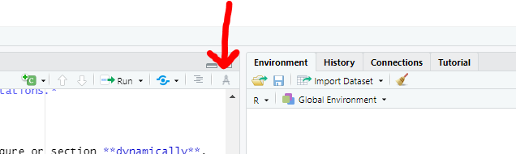

Visual Editor

In this mode you can write in a format more similar to other word processors (in stead of markdown syntax).

The key advantage is how it can help with citations.

All you have to do is type @ and the editor will start to autofill suggestions for references and prompt to add it to a .bib file.

[figure not shown]

## Special Topics

## Recommended Packages

- `dplyr`
- `tidyr`
- `purrr`
- `flextable`

## For Parallel Processing

- `doParallel`
- `doRNG`

## For Network Analysis

- `igraph`
- `networkD3` (?)

## Random Stuff I’ve Done With R

- Browser Automation for Web-Scraping
- Shiny Apps and Interactive Documents
- Semi-Automated Lit Review